# eda

2025-04-23

🧠 Project Focus: SMART Questions Based on your earlier message, your project investigates:

Can earnings be predicted by field of study, degree level, and aid profile?

Do high Pell Grant programs lead to systematically lower earnings?

Do online programs yield different earnings than in-person ones?

🧭 Step-by-Step Strategy ✅ 1. Data Import Import the original College Scorecard Field of Study dataset

Ensure earnings and aid variables are properly loaded as numeric

✅ 2. Data Cleaning Select only relevant variables (earnings, Pell %, degree type, delivery mode, field name)

Convert character columns to numeric where needed

Handle missing values as appropriate

✅ 3. Exploratory Data Analysis (EDA) Plot distributions of earnings overall and by subgroup:

By major (field of study)

By credential level

By Pell Grant level

By delivery mode (distance vs in-person)

✅ 4. Statistical Testing and Modeling (Later) T-tests, ANOVA, or regression to answer your questions quantitatively

```
## [1] 229188    174
```

```
## # A tibble: 6 × 174
##   UNITID OPEID6 INSTNM            CONTROL  MAIN CIPCODE CIPDESC CREDLEV CREDDESC
##    <dbl> <chr>  <chr>             <chr>   <dbl> <chr>   <chr>     <dbl> <chr>
## 1 100654 001002 Alabama A & M Un… Public      1 0100    Agricu…       3 Bachelo…
## 2 100654 001002 Alabama A & M Un… Public      1 0101    Agricu…       3 Bachelo…
## 3 100654 001002 Alabama A & M Un… Public      1 0109    Animal…       3 Bachelo…
## 4 100654 001002 Alabama A & M Un… Public      1 0110    Food S…       3 Bachelo…
## 5 100654 001002 Alabama A & M Un… Public      1 0110    Food S…       5 Master'…
## 6 100654 001002 Alabama A & M Un… Public      1 0110    Food S…       6 Doctora…
## # ℹ 165 more variables: IPEDSCOUNT1 <dbl>, IPEDSCOUNT2 <dbl>,
## #   DEBT_ALL_STGP_ANY_N <chr>, DEBT_ALL_STGP_ANY_MEAN <chr>,
## #   DEBT_ALL_STGP_ANY_MDN <chr>, DEBT_ALL_STGP_EVAL_N <chr>,
## #   DEBT_ALL_STGP_EVAL_MEAN <chr>, DEBT_ALL_STGP_EVAL_MDN <chr>,
## #   DEBT_ALL_PP_ANY_N <chr>, DEBT_ALL_PP_ANY_MEAN <chr>,
## #   DEBT_ALL_PP_ANY_MDN <chr>, DEBT_ALL_PP_EVAL_N <chr>,
## #   DEBT_ALL_PP_EVAL_MEAN <chr>, DEBT_ALL_PP_EVAL_MDN <chr>, …
```

#📊 SMART Q1: Can earnings be predicted by field, degree, and aid?

```r
# FVerifying that we have ther right variables
grep("earn", names(field_data), value = TRUE, ignore.case = TRUE)
```

```
##  [1] "EARN_COUNT_NWNE_HI_1YR"    "EARN_CNTOVER150_HI_1YR"
##  [3] "EARN_COUNT_WNE_HI_1YR"     "EARN_MDN_HI_1YR"
##  [5] "EARN_COUNT_NWNE_HI_2YR"    "EARN_CNTOVER150_HI_2YR"
##  [7] "EARN_COUNT_WNE_HI_2YR"     "EARN_MDN_HI_2YR"
##  [9] "EARN_COUNT_PELL_WNE_1YR"   "EARN_PELL_WNE_MDN_1YR"
## [11] "EARN_COUNT_NOPELL_WNE_1YR" "EARN_NOPELL_WNE_MDN_1YR"
## [13] "EARN_COUNT_MALE_WNE_1YR"   "EARN_MALE_WNE_MDN_1YR"
## [15] "EARN_COUNT_NOMALE_WNE_1YR" "EARN_NOMALE_WNE_MDN_1YR"
## [17] "EARN_COUNT_NE_3YR"         "EARN_NE_MDN_3YR"
## [19] "EARN_COUNT_WNE_3YR"        "EARN_CNTOVER150_3YR"
## [21] "EARN_COUNT_PELL_NE_3YR"    "EARN_PELL_NE_MDN_3YR"
## [23] "EARN_COUNT_NOPELL_NE_3YR"  "EARN_NOPELL_NE_MDN_3YR"
## [25] "EARN_COUNT_MALE_NE_3YR"    "EARN_MALE_NE_MDN_3YR"
## [27] "EARN_COUNT_NOMALE_NE_3YR"  "EARN_NOMALE_NE_MDN_3YR"
## [29] "EARN_COUNT_NWNE_1YR"       "EARN_COUNT_WNE_1YR"
```

[output cut: 16 more lines]

```r
grep("pell", names(field_data), value = TRUE, ignore.case = TRUE)
```

```
##  [1] "DEBT_PELL_STGP_ANY_N"       "DEBT_PELL_STGP_ANY_MEAN"
##  [3] "DEBT_PELL_STGP_ANY_MDN"     "DEBT_PELL_STGP_EVAL_N"
##  [5] "DEBT_PELL_STGP_EVAL_MEAN"   "DEBT_PELL_STGP_EVAL_MDN"
##  [7] "DEBT_PELL_PP_ANY_N"         "DEBT_PELL_PP_ANY_MEAN"
##  [9] "DEBT_PELL_PP_ANY_MDN"       "DEBT_PELL_PP_EVAL_N"
## [11] "DEBT_PELL_PP_EVAL_MEAN"     "DEBT_PELL_PP_EVAL_MDN"
## [13] "DEBT_NOPELL_STGP_ANY_N"     "DEBT_NOPELL_STGP_ANY_MEAN"
## [15] "DEBT_NOPELL_STGP_ANY_MDN"   "DEBT_NOPELL_STGP_EVAL_N"
## [17] "DEBT_NOPELL_STGP_EVAL_MEAN" "DEBT_NOPELL_STGP_EVAL_MDN"
## [19] "DEBT_NOPELL_PP_ANY_N"       "DEBT_NOPELL_PP_ANY_MEAN"
## [21] "DEBT_NOPELL_PP_ANY_MDN"     "DEBT_NOPELL_PP_EVAL_N"
## [23] "DEBT_NOPELL_PP_EVAL_MEAN"   "DEBT_NOPELL_PP_EVAL_MDN"
## [25] "EARN_COUNT_PELL_WNE_1YR"    "EARN_PELL_WNE_MDN_1YR"
## [27] "EARN_COUNT_NOPELL_WNE_1YR"  "EARN_NOPELL_WNE_MDN_1YR"
## [29] "EARN_COUNT_PELL_NE_3YR"     "EARN_PELL_NE_MDN_3YR"
## [31] "EARN_COUNT_NOPELL_NE_3YR"   "EARN_NOPELL_NE_MDN_3YR"
## [33] "EARN_COUNT_PELL_WNE_4YR"    "EARN_PELL_WNE_MDN_4YR"
## [35] "EARN_COUNT_NOPELL_WNE_4YR"  "EARN_NOPELL_WNE_MDN_4YR"
## [37] "EARN_COUNT_PELL_WNE_5YR"    "EARN_PELL_WNE_MDN_5YR"
## [39] "EARN_COUNT_NOPELL_WNE_5YR"  "EARN_NOPELL_WNE_MDN_5YR"
```

```r
grep("loan", names(field_data), value = TRUE, ignore.case = TRUE)
```

```
## character(0)
```

```r
grep("distance", names(field_data), value = TRUE, ignore.case = TRUE)
```

```
## [1] "DISTANCE"
```

```r
grep("credlev", names(field_data), value = TRUE, ignore.case = TRUE)
```

```
## [1] "CREDLEV"
```

```r
grep("cipdesc", names(field_data), value = TRUE, ignore.case = TRUE)
```

```
## [1] "CIPDESC"
```

```r
grep("income", names(field_data), value = TRUE, ignore.case = TRUE)
```

```
## character(0)
```

```r
grep("earn", names(field_data), value = TRUE, ignore.case = TRUE)
```

```
##  [1] "EARN_COUNT_NWNE_HI_1YR"    "EARN_CNTOVER150_HI_1YR"
##  [3] "EARN_COUNT_WNE_HI_1YR"     "EARN_MDN_HI_1YR"
##  [5] "EARN_COUNT_NWNE_HI_2YR"    "EARN_CNTOVER150_HI_2YR"
##  [7] "EARN_COUNT_WNE_HI_2YR"     "EARN_MDN_HI_2YR"
##  [9] "EARN_COUNT_PELL_WNE_1YR"   "EARN_PELL_WNE_MDN_1YR"
## [11] "EARN_COUNT_NOPELL_WNE_1YR" "EARN_NOPELL_WNE_MDN_1YR"
## [13] "EARN_COUNT_MALE_WNE_1YR"   "EARN_MALE_WNE_MDN_1YR"
## [15] "EARN_COUNT_NOMALE_WNE_1YR" "EARN_NOMALE_WNE_MDN_1YR"
## [17] "EARN_COUNT_NE_3YR"         "EARN_NE_MDN_3YR"
## [19] "EARN_COUNT_WNE_3YR"        "EARN_CNTOVER150_3YR"
## [21] "EARN_COUNT_PELL_NE_3YR"    "EARN_PELL_NE_MDN_3YR"
## [23] "EARN_COUNT_NOPELL_NE_3YR"  "EARN_NOPELL_NE_MDN_3YR"
## [25] "EARN_COUNT_MALE_NE_3YR"    "EARN_MALE_NE_MDN_3YR"
## [27] "EARN_COUNT_NOMALE_NE_3YR"  "EARN_NOMALE_NE_MDN_3YR"
## [29] "EARN_COUNT_NWNE_1YR"       "EARN_COUNT_WNE_1YR"
```

[output cut: 16 more lines]

Pull Aid Info from institute_data

```r
# Extract aid-related info from institution-level data
aid_vars <- institute_data %>%
  select(UNITID, PCTPELL, PCTFLOAN) %>%
  mutate(
    PCTPELL = as.numeric(PCTPELL),
    PCTFLOAN = as.numeric(PCTFLOAN)
  )

# Merge into field-level data
field_clean <- field_data %>%
  select(UNITID, EARN_MDN_1YR, CREDLEV, CIPDESC, DISTANCE) %>%
  left_join(aid_vars, by = "UNITID") %>%
  mutate(
    EARN_MDN = as.numeric(EARN_MDN_1YR),
    CREDLEV = factor(CREDLEV),
    DISTANCE = factor(DISTANCE, levels = c(0, 1), labels = c("In-Person", "Online"))
  ) %>%
  filter(!is.na(EARN_MDN))
```

📊 Earnings by Credential Level

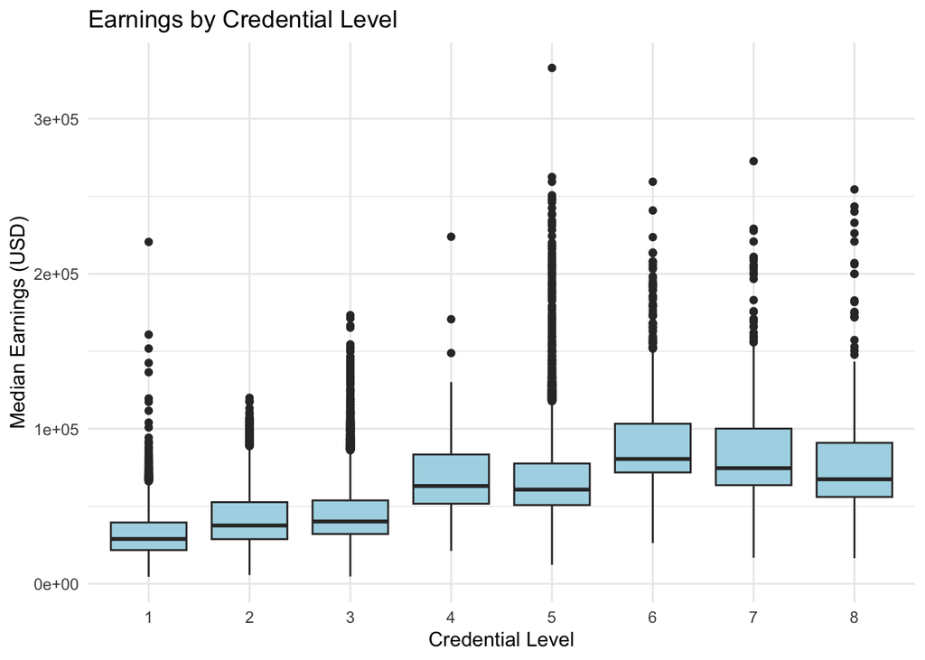

```r
library(ggplot2)

ggplot(field_clean, aes(x = CREDLEV, y = EARN_MDN)) +
  geom_boxplot(fill = "lightblue") +
  labs(title = "Earnings by Credential Level", x = "Credential Level", y = "Median Earnings (USD)") +
  theme_minimal()
```